## HOMEWORK 5 Ivan Sanchez Fernandez

Instructions: You are to complete and turn in this problem set by Thursday, October 5 at 9:59am (immediately before class). Problem sets may be turned in within 24 hours late at a 20% grading penalty. The final problem will show you how to turn in your problem set. All code should be included in the submission, and should be saved in an r markdown file. Any answers should be included as comments immediately below the code responsible, and should be labelled as follows: # CODE 2a Put your code here and if you need another line, put it here, and also here! # ANSWER 2a # Put your answer for 2a here If you have any questions, please post on the piazza site. This problem set was prepared by Eric Bartell, Jacob Luber and Tiziana Sanavia, so they will be most prepared to answer questions. Point values are relative, and will be scaled to 100%. Data are available in the following link, in the pset5 folder: https://www.dropbox.com/sh/rlj714terrzakc7/ AACELk752w4GPAsJXYi8Vbb5a?dl=0

## Question 1

Flight Paths For this question, we will be using flightInfo.tsv to consider a simple graph.

1.1 Pull in data (1 point) Get the data in a usable format. For this problem you should be using the igraph (http://igraph.org/r/) package. Our small file consists of city names, and flight costs and flight times between the cities. Each row represents an undirected edge between cities (nodes). First load the file as a dataframe, and then use the igraph method graph_from_data_frame(flight info dataframe) to obtain an object. Assume that the cost and time is the same to fly in both directions; as such this should be an undirected graph. Using the class() function, what is our loaded data’s type?

```r
## CODE 1.1

#I load the database
flights <- read.table("F:\\BMI715 Computing Skills for Biomedical Sciences\\Homework5\\pset5\\flightInfo.tsv", header = TRUE, sep = "\t")

#I check that it is a dataframe
class(flights)
```

```
## [1] "data.frame"
```

```r
#install.packages("igraph")
library(igraph)
#I create a graph file
graphflights <- graph_from_data_frame(flights, directed = FALSE)

#and check that it is and igraph object
class(graphflights)
```

```
## [1] "igraph"
```

```r
## ANSWER 1.1
#The uploaded file is of class igraph
```

1.2 Basic plotting (2 points) Once you have loaded in the data, plot it using plot(). What is the Node Degree of New York? Your plot should look something like this:

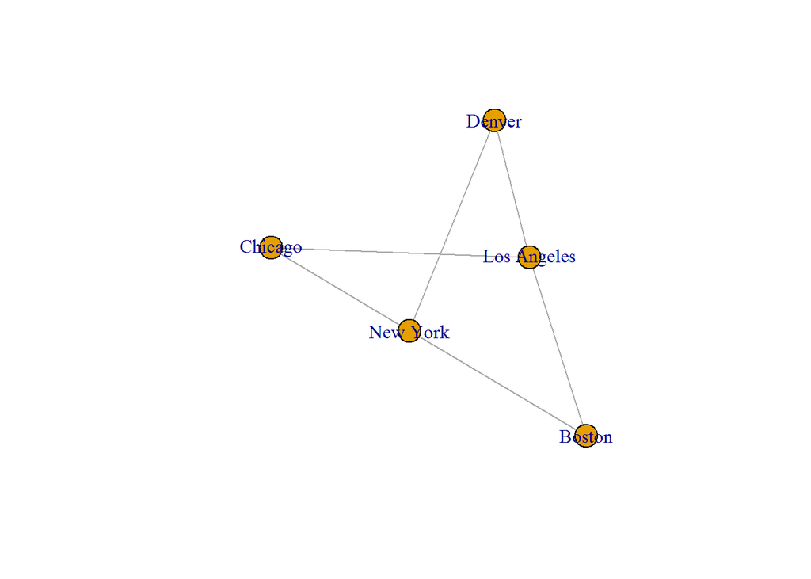

```r
## CODE 1.2

#I plot the graph
plot(graphflights)
```

```r
#I check the degree of each node
degree(graphflights)
```

```
##      Boston    New York     Chicago      Denver Los Angeles
##           2           3           2           2           3
```

```r
## ANSWER 1.2
#Based on the graph and the output from the degree() function, the node degree of New York is 3
```

1.3 Plot using ggraph (3 points) igraph interacts well with the ggplot addon ggraph. Install and load it, and then use ggraph() and its related functions to plot the same graph as part 1.2. Hint: remember, ggrap() (like ggplot()) instantiates the plot, but you still need to add features you want to include (like nodes and edges)! Make sure you label each node with it’s name! It should look something like this:

```
## Using `nicely` as default layout
```

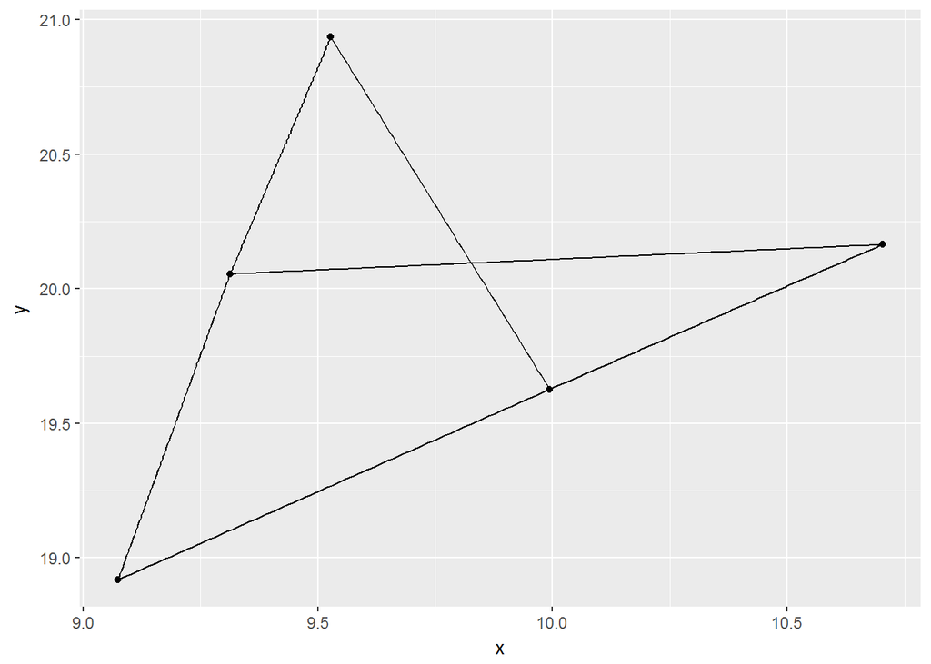

```r
## CODE 1.3

#install.packages("ggraph")
library(ggraph)
#I plot the basic graph
ggraph(graphflights) + geom_node_point() + geom_edge_link()
```

```
## Using `nicely` as default layout
```

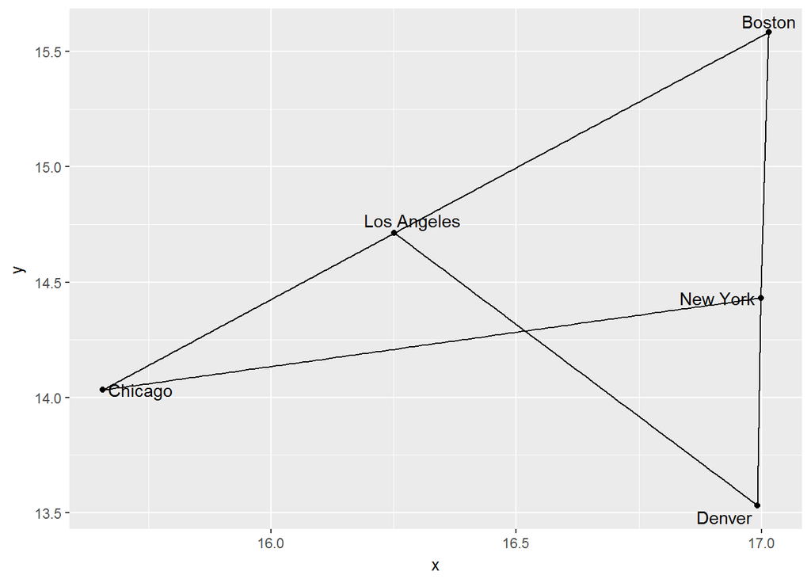

```r
#I use the names in the vertex attributes as vertex labels
ggraph(graphflights) + geom_node_point() + geom_edge_link() + geom_node_text(mapping = aes(label = vertex_attr(graphflights)$name), repel = TRUE)
```

```
## Using `nicely` as default layout
```

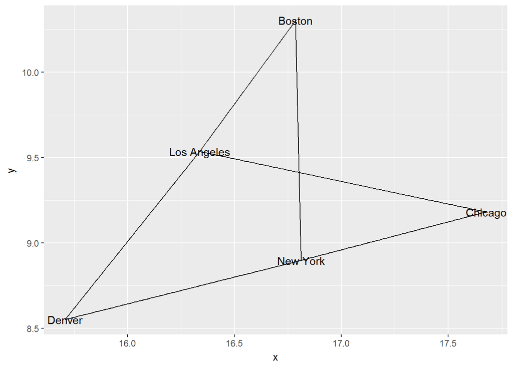

```r
#And now without points in the nodes and with no separation of the labels from the nodes to make it similar to the solution in the exercise
ggraph(graphflights) + geom_edge_link() + geom_node_text(mapping = aes(label = vertex_attr(graphflights)$name), repel = FALSE)
```

1.4 Add information to the plot (3 points) Re-plot the graph from 1.3 (using ggraph and related functions); label each edge with the cost of that edge, and change the transparency of the edge to correlate with the time for each trip (e.g. transparency = Time/max(Times)).

```
## Using `nicely` as default layout
```

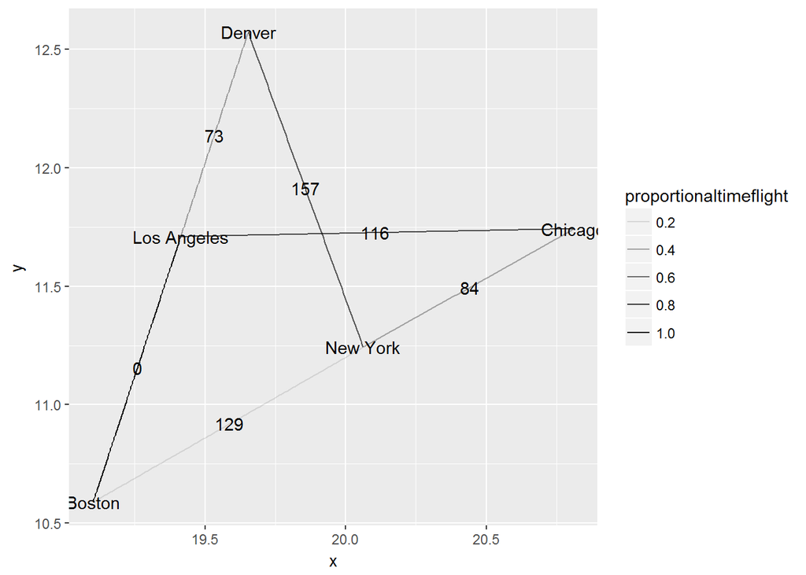

```r
## CODE 1.4

#I create the variable proportional time flight as the flight duration divided by the maximum flight duration
proportionaltimeflight <- edge_attr(graphflights)$Time / max(edge_attr(graphflights)$Time)

#I graph the results
ggraph(graphflights) +
  geom_edge_link(mapping = c(aes(label = edge_attr(graphflights)$Cost), aes(alpha = proportionaltimeflight))) +
  geom_node_text(mapping = aes(label = vertex_attr(graphflights)$name), repel = FALSE)
```

## Question 2

Gene Networks In this question, we are going to create a gene network based on the pairwise correlation of 50 genes measured using their expression profiles across 50 samples. For more reading on correlation analysis/co-expression networks, Nils’ paper (https://paperpile.com/app/p/ 7eb28d4c-c172-0f88-811e-f443a9f05fad) contains a short section entitled “Network clustering and correlation networks.”

```r
## CODE 2.1

#I load the database
geneData <- read.table("F:\\BMI715 Computing Skills for Biomedical Sciences\\Homework5\\pset5\\Network_Expression_Data.txt", header = TRUE, sep = "\t")

#I check that it is a dataframe
class(geneData)
```

```
## [1] "data.frame"
```

```r
#Dimensions
dim(geneData)
```

```
## [1] 50 50
```

```r
## ANSWER 2.1
#The dataframe has 50 rows and 50 columns
```

Calculate a gene-gene distance matrix where we define Distance = 1 - abs(correlation(GeneA, GeneB)). Use spearman correlation (cor(x , method=“spearman”)). This distance matrix will be the adjacency matrix for our network, which is a square matrix used to represent a finite graph. The elements of the matrix indicate whether pairs of vertices are adjacent or not in the graph. NOTE: you need to transpose your data.

```r
## CODE 2.1

#I create the gene correlation matrix
geneDistances <- 1 - abs(cor(t(geneData), method = "spearman"))

#I check that it looks more or less as expected
geneDistances[1:10, 1:5]
```

```
##            YPEL1      DMC1    RSPH14      REC8      CD40
## YPEL1  0.0000000 0.4190156 0.3407443 0.4505162 0.2732293
## DMC1   0.4190156 0.0000000 0.3323890 0.2896519 0.1856423
## RSPH14 0.3407443 0.3323890 0.0000000 0.3584154 0.2626651
## REC8   0.4505162 0.2896519 0.3584154 0.0000000 0.2447059
## CD40   0.2732293 0.1856423 0.2626651 0.2447059 0.0000000
## PLP2   0.2149340 0.3640816 0.2385594 0.3130852 0.1807443
## ESRP2  0.3997119 0.2801441 0.3466026 0.2954142 0.2870588
## QPRT   0.4109484 0.1131333 0.2935894 0.2573830 0.1887155
## RASL12 0.4384154 0.1854502 0.3189436 0.2334694 0.2514286
## RAB3D  0.3127971 0.3057863 0.3271068 0.2431693 0.2516206
```

```r
#I check that dimensions are 50 rows and 50 columns
dim(geneDistances)
```

```
## [1] 50 50
```

2.2 Describe the data (2 points) How many vertices are in the dataset defined by our distance matrix? How many edges? What is each vertex’s degree? Assume no self-loops.

```r
## CODE 2.2

#I check that dimensions are 50 rows and 50 columns
dim(geneDistances)
```

```
## [1] 50 50
```

```r
#I check the structure of the matrix
geneDistances
```

[output not shown]

[output cut: 404 more lines]

```
## NECAB1   0.3933733 0.2161825
## RAB9B    0.3302761 0.1606723
## G0S2     0.4087395 0.3746459
## RAB17    0.1658583 0.2436495
## DOK4     0.2544058 0.1575990
## TMTC4    0.2306843 0.1917887
## ABCC4    0.3216327 0.3777191
## PAX1     0.6835755 0.6080258
## FGFRL1   0.3105882 0.2230012
## LRFN1    0.3272989 0.3455462
## HOXD13   0.3466026 0.1673950
## SOX15    0.3333493 0.2269388
## CDKN1C   0.3955822 0.4217047
## SMPDL3B  0.0000000 0.2531573
## RGN      0.2531573 0.0000000
```

```r
#I check that correlation = 0 only occurs in the 50 diagonal lines
table(geneDistances == 0)
```

```
##
## FALSE  TRUE
##  2450    50
```

```r
## ANSWER 2.2
#There are 50 vertices (nodes) in the matrix corresponding to each gene and each of the columns (or rows)
#Each node is connected to 49 nodes, so the degree of each node is 49
#As each node is connected to 49 nodes and each connection is undirected, the total number of edges would be
# n * (n - 1) / 2
49 * 50 / 2
```

```
## [1] 1225
```

```r
# 1225 edges
```

2.3 Make a more useful dataset (6 point) First, load the graph using igraph package and create the network using the command of the package specific for the adjacency matrix. Load the network as undirected, exclude the elements along the diagonal in order to avoid self-loops and keep the weights defined by your correlation-based distance. Up to now, we are considering all genes as connected; this is not a very useful dataset. If we set a threshold based on the distance defined above, we can subset our edges to get more information out of our graph. Create a threshold on distance: if distance is greater than 0.2, remove the edge using the command delete.edges. Remove the nodes that do not share any edges using the command delete.vertices.

```r
## CODE 2.3

#I create the igraph object
graphgenes <- graph_from_adjacency_matrix(geneDistances, mode = "undirected", diag = FALSE, weight = TRUE)

#I check that it is an igraph object
class(graphgenes)
```

```
## [1] "igraph"
```

```r
#I delete edges with distance greater than 0.2
graphgenesclean <- delete.edges(graphgenes, which(E(graphgenes)$weight > 0.2))

#I delete nodes with no connections (degree = 0)
graphgenesclean <- delete.vertices(graphgenesclean, which(degree(graphgenesclean) == 0))
```

Display the final graph using ggraphs() in two ways: 1. We are going to graph our genes. We will: color edges by their distance, label our nodes, annotate our nodes by their degree, and space our nodes such that thee graph is readable. You only need to turn in the final graph; however, these steps should facilitate your graph creation process. First, we instantiate our graph with the layout “Kamada-Kawai”, and add edges that are colored by Distance between edges. You may want to use the E() function to get access to edge distances.

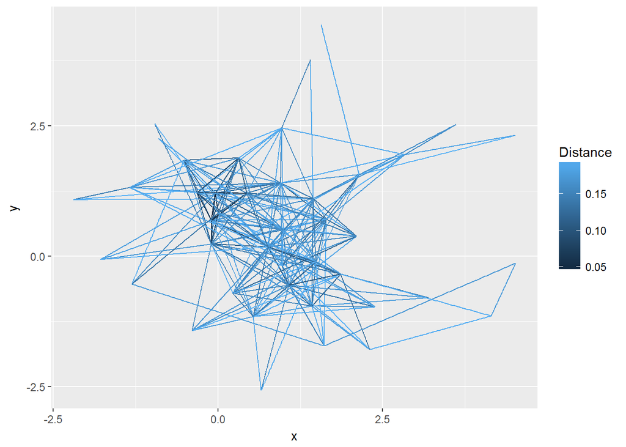

```r
## CODE 2.3

#I define the variable Distance
Distance <- E(graphgenesclean)$weight

#I instantiate the graph with the layout Kamada-Kawai and add edges colored by distance
ggraph(graphgenesclean, layout = "kk") +
  geom_edge_link(mapping = aes(color = Distance)) +
  geom_node_text(label = "")
```

Now, we want to control the edge coloring: use scale_edge_colour_gradient() with “red” for low distances and “yellow” for high distances.

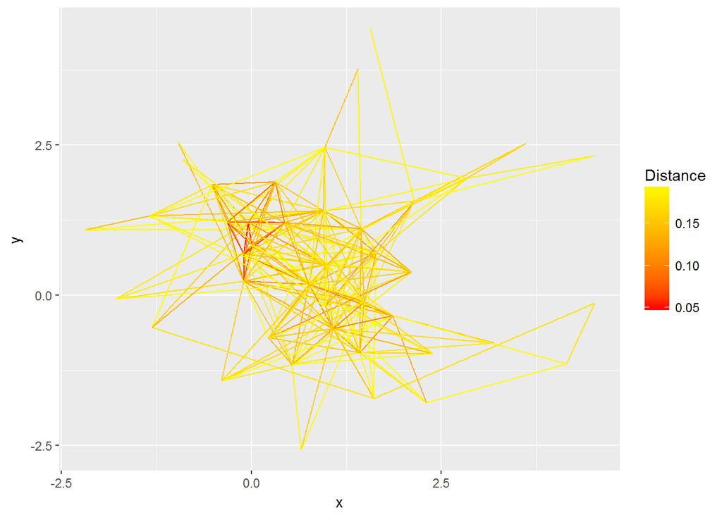

```r
## CODE 2.3

#I color the edges with red for low distances and yellow for high distances
ggraph(graphgenesclean, layout = "kk") +
  geom_edge_link(mapping = aes(color = Distance)) +
  geom_node_text(label = "") +
  scale_edge_colour_gradient(low = "red", high = "yellow")
```

Awesome. Next we want to label each of our nodes with the Name of the gene. Consider geom_node_text(); use the font “Courier”, fontface “bold”, and make sure to use repel=T.

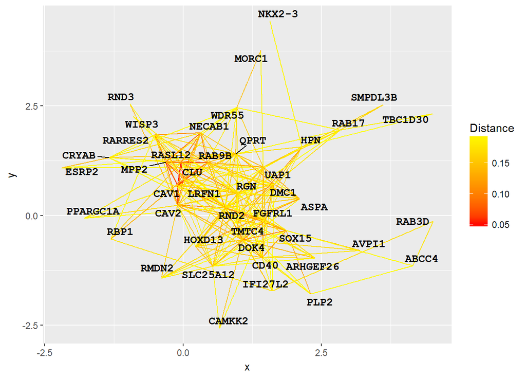

```r
## CODE 2.3

#I label the nodes with the name of the gene, use Courier (mono in Windows) and bold, and use repel
ggraph(graphgenesclean, layout = "kk") +
  geom_edge_link(mapping = aes(color = Distance)) +
  geom_node_text(mapping = aes(label = vertex_attr(graphgenesclean)$name), family = "mono", fontface = "bold", repel = TRUE) +
  scale_edge_colour_gradient(low = "red", high = "yellow")
```

```r
#Apparently "mono" is how "Courier" appears in Windows
```

Finally, we would like to characterize our nodes based on whether their degree is >10 or <10. You may want to create an object that signifies which category your node falls into. Also, use theme_void() to remove the background.

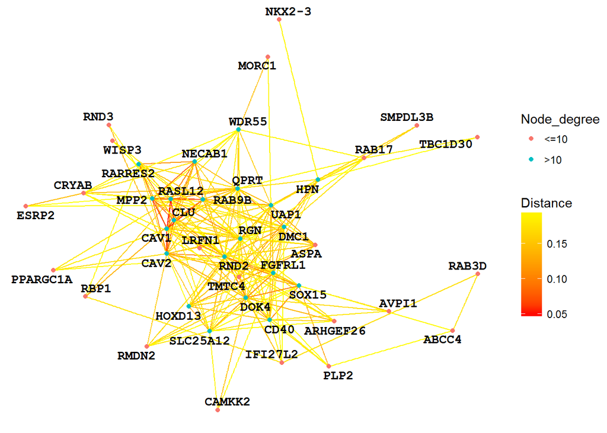

```r
## CODE 2.3

#I create Node_degree
Node_degree <- ifelse(degree(graphgenesclean) > 10, ">10", "<=10")

#I add the degree as a binary variable
ggraph(graphgenesclean, layout = "kk") +
  geom_edge_link(mapping = aes(color = Distance)) +
  geom_node_text(mapping = aes(label = vertex_attr(graphgenesclean)$name), family = "mono", fontface = "bold", repel = TRUE) +
  scale_edge_colour_gradient(low = "red", high = "yellow") +
  geom_node_point(mapping = aes(color = Node_degree)) +
  theme_void()
```

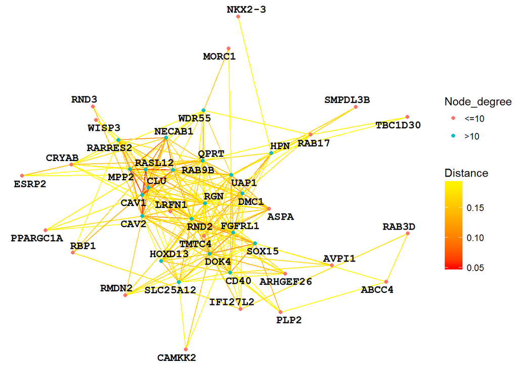

```r
#Final graph 1
finalgraph1 <- ggraph(graphgenesclean, layout = "kk") +
  geom_edge_link(mapping = aes(color = Distance)) +
  geom_node_text(mapping = aes(label = vertex_attr(graphgenesclean)$name), family = "mono", fontface = "bold", repel = TRUE) +
  scale_edge_colour_gradient(low = "red", high = "yellow") +
  geom_node_point(mapping = aes(color = Node_degree)) +
  theme_void()
finalgraph1
```

Well done! We’ve plotted genes by their similarity to each other! 2. repeat the point 1 by changing the format to a circular graph as displayed in the figure. Use this link as reference: https://cran.r-project.org/web/packages/ggraph/vignettes/Edges.html

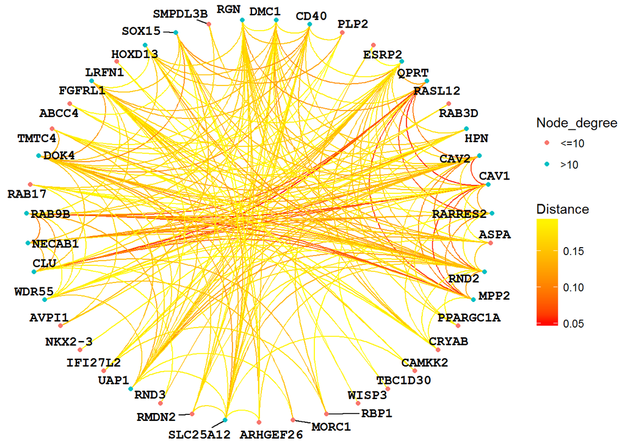

```r
## CODE 2.3

#Final graph 2
finalgraph2 <- ggraph(graphgenesclean, layout = "linear", circular = TRUE) +
  geom_edge_arc(mapping = aes(color = Distance)) +
  geom_node_text(mapping = aes(label = vertex_attr(graphgenesclean)$name), family = "mono", fontface = "bold", repel = TRUE) +
  scale_edge_colour_gradient(low = "red", high = "yellow") +
  geom_node_point(mapping = aes(color = Node_degree)) +
  theme_void()
finalgraph2
```

2.4 Describe the data, part 2 (2 points) Plot the distribution of node degree in our new graph. How many edges are there now? Which gene(s) are the most connected?

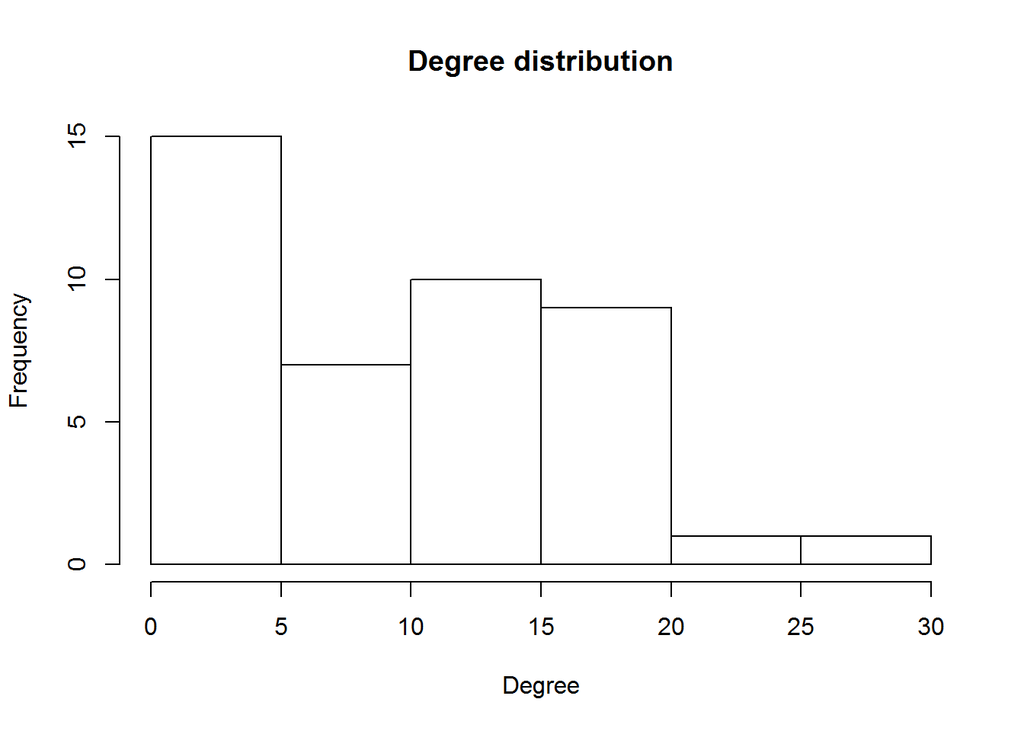

```r
## CODE 2.4

#I create an histogram of node degree
hist(degree(graphgenesclean), main = "Degree distribution", xlab = "Degree")
```